# ActivityMonitoring1

Nikolos Peyralans

March 31, 2016

1.Code for reading in the dataset and/or processing the data Read in the dataset, and convert date to Date object:

```r
data <- read.csv("activity.csv", na.strings = "NA")
data$date <- as.Date(as.character(data$date))
```

2.Histogram of the total number of steps taken each day Get the total steps for each date in the data and plot:

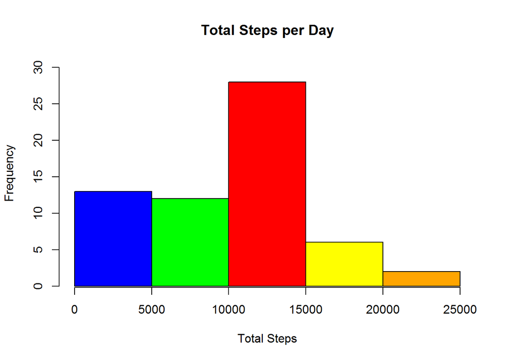

```r
library(dplyr)
total_steps_per_day <- summarise(group_by(data, date), sum(steps, na.rm = TRUE))
names(total_steps_per_day) <- c("date", "total_steps")

hist(total_steps_per_day$total_steps, xlab = "Total Steps", main = "Total Steps per Day", col = c("blue", "green", "red", "yellow", "orange"), ylim = c(1,30))
```

3.Mean and median number of steps taken each day

```r
mean(total_steps_per_day$total_steps)
```

```
## [1] 9354.23
```

```r
median(total_steps_per_day$total_steps)
```

```
## [1] 10395
```

4.Time series plot of the average number of steps taken Divide step averages by the time interval and plot:

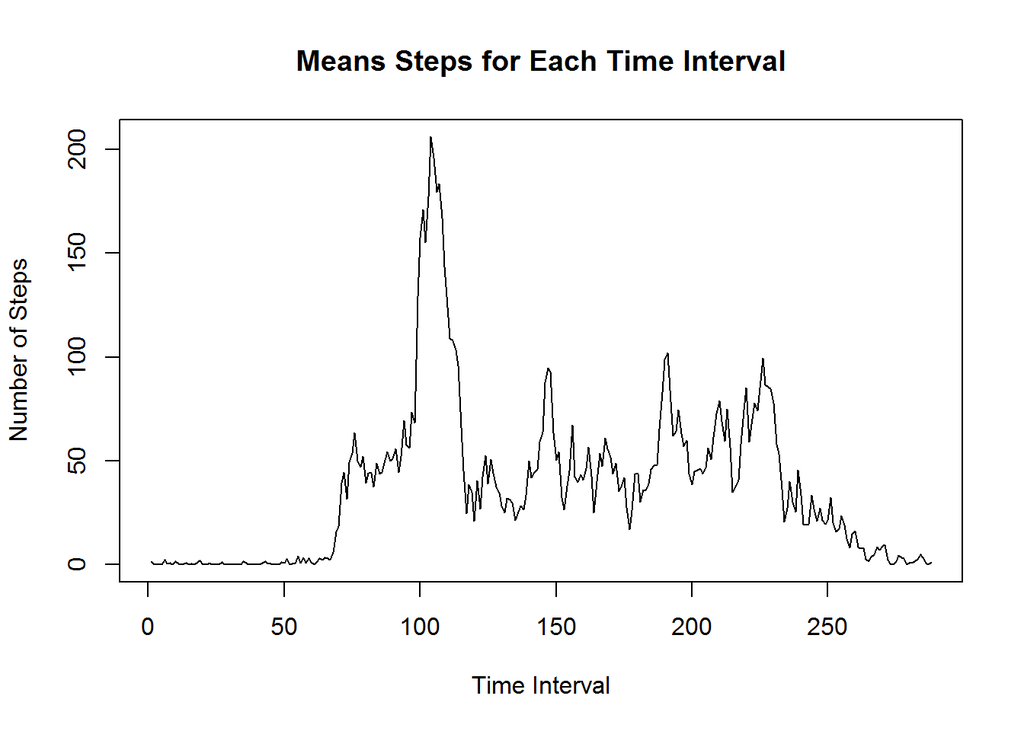

```r
mean_steps_per_interval <- tapply(data$steps, data$interval, mean, na.rm=TRUE)

plot(mean_steps_per_interval, type="l", main="Means Steps for Each Time Interval", ylab="Number of Steps", xlab = "Time Interval")
```

```r
mean_steps_per_interval <- aggregate(steps ~ interval, data, mean)
max_row <- which.max(mean_steps_per_interval$steps)
max_interval <- mean_steps_per_interval[max_row,]
```

6.Code to describe and show a strategy for imputing missing data

Find total number of missing values:

```r
bad <- data[is.na(data),]
num_bad <- nrow(bad)
percent_bad <- num_bad/nrow(data)
```

Replace missing values in their time interval with the mean steps for that time interval

```r
data_with_impute <- data
for ( i in 1:nrow(data_with_impute)) {
  if ( is.na(data_with_impute$steps[i])){
    interval <- data_with_impute$interval[i]
    row_id <- which(mean_steps_per_interval$interval==interval)
    impute_val <- mean_steps_per_interval$steps[row_id]
    data_with_impute$steps[i] <- impute_val
  }
}
##verify
sum(is.na(data_with_impute$steps))
```

```
## [1] 0
```

```r
sum(is.na(data$steps))
```

```
## [1] 2304
```

7.Histogram of the total number of steps taken each day after missing values are imputed

Redo the analysis above with imputed data:

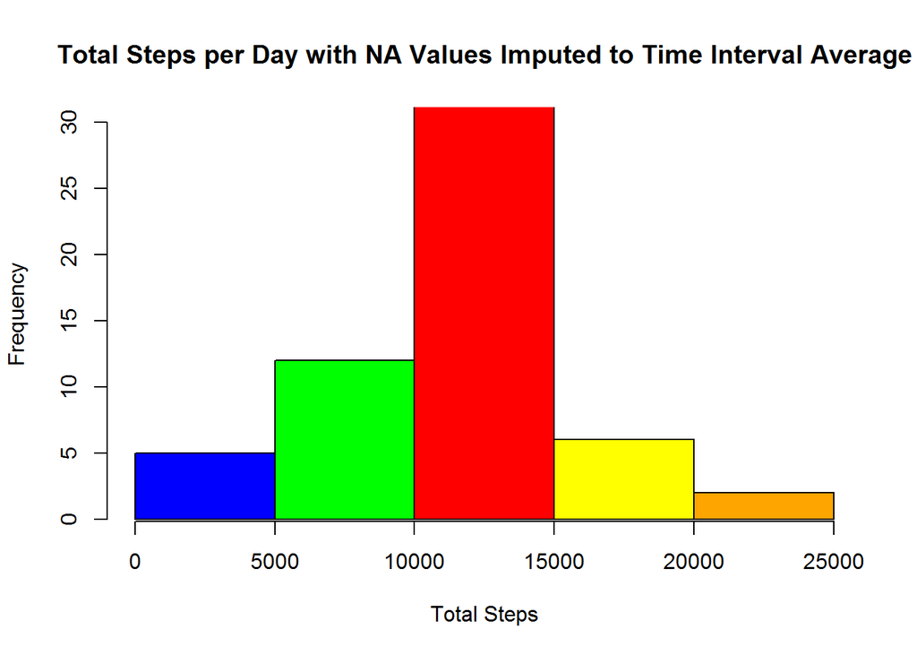

```r
daily_totals_imputed <- summarise(group_by(data_with_impute, date), sum(steps, na.rm = TRUE))
names(daily_totals_imputed) <- c("date", "total_steps")

hist(daily_totals_imputed$total_steps, xlab = "Total Steps", main = "Total Steps per Day with NA Values Imputed to Time Interval Average", col = c("blue", "green", "red", "yellow", "orange"), ylim = c(1,30))
```

```r
mean(daily_totals_imputed$total_steps)
```

```
## [1] 10766.19
```

```r
median(daily_totals_imputed$total_steps)
```

```
## [1] 10766.19
```

Add a column for day of the week, and for weekend or not:

```r
data_with_impute$day <- weekdays(data_with_impute$date)
##data_with_impute$day <- as.factor(data_with_impute$day)
for ( i in 1:nrow(data_with_impute) ) {
  if ( data_with_impute$day[i] == "Saturday" || data_with_impute$day[i] == "Sunday" ) { data_with_impute$weekend[i] <- "weekend" } else { data_with_impute$weekend[i] <- "weekday" }
}
##factorize
data_with_impute$weekend <- as.factor(data_with_impute$weekend)
```

Make the panel plot:

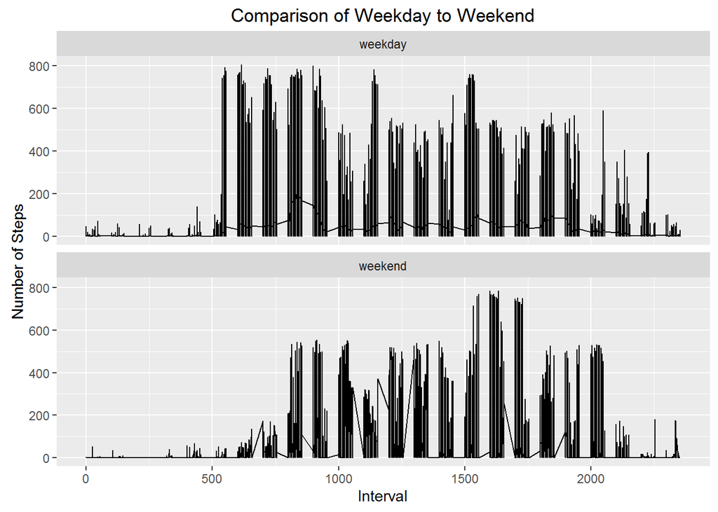

```r
library(ggplot2)
qplot(interval, steps, data=data_with_impute, geom=c("line"),
  xlab="Interval", ylab="Number of Steps", main="Comparison of Weekday to Weekend") + facet_wrap(~ weekend, ncol=1)
```